# Course project - Machine learning

Michael N.

2/3/2021

## Excutive summary

The goal of your project is to predict the manner in which they did the exercise. This is the “classe” variable in the training set. You may use any of the other variables to predict with. You should create a report describing how you built your model, how you used cross validation, what you think the expected out of sample error is, and why you made the choices you did. You will also use your prediction model to predict 20 different test cases.

## Exploratory Data analysis

```r
training <- read.csv("pml-training.csv")
testing <- read.csv("pml-testing.csv")
```

```r
dim(training)
```

```
## [1] 19622   160
```

The dataset in composed of 19622 observations and 160 variables. If we explore the dataset, we would notice than many column have NAs and some with empty values that aren’t NAs, which can’t be used for predicting. First step would thus be to clean the dataset and keep only the columns that are useful.

## Data Preparation

### Data Cleaning

Now let’s reduce the size of the dataset as it is quite large and many variables aren’t useful for our prediction, such as NAs or empty values, low variability variables and extraneous variables (first 6 columns).

```r
# Removing NAs
NAs <- which(colSums(is.na(training)) != 0)
training <- training[ ,-NAs]

# Removing covariates with little to no variability in them (it also helps in removing columns with empty values)
nzv <- nearZeroVar(training)
training <- training[,-nzv]

#Removing extraneous variables
training <- training[,-c(1:6)]

dim(training)
```

```
## [1] 19622    53
```

As we can see we reduced our number of variables from 160 to 53 (including the response variable). This will make model building much more efficient.

### Data slicing

Now that our dataset is clean, let’s partition the training data into a train and test set.

```r
set.seed(1000)
inTrain <- createDataPartition(training$classe, p=0.7, list=F)
train <- training[inTrain, ]
test <- training[-inTrain, ]
```

## Model Building

In this section, I’ll build 3 different models and select the most accurate one to predict the testing dataset. The models that I’ll try are decision trees, random forest and gradient boosting as they are effective for classification.

### Decision Trees

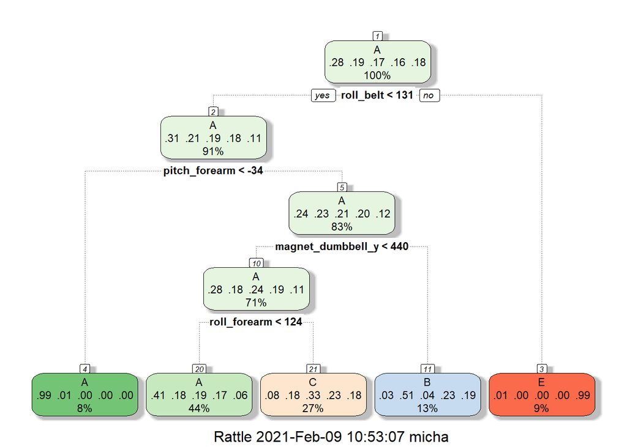

```r
modFitRpart <- train(classe ~., method = "rpart", data=train)
fancyRpartPlot(modFitRpart$finalModel)
```

```r
predictRpart <- predict(modFitRpart,newdata=test)
confusionMatrix(as.factor(test$classe), predictRpart)
```

```
## Confusion Matrix and Statistics
##
##           Reference
## Prediction    A    B    C    D    E
##          A 1523   27  121    0    3
##          B  487  396  256    0    0
##          C  474   34  518    0    0
##          D  445  165  354    0    0
##          E  173  154  291    0  464
##
## Overall Statistics
##
##                Accuracy : 0.4929
##                  95% CI : (0.4801, 0.5058)
##     No Information Rate : 0.5271
##     P-Value [Acc > NIR] : 1
##
##                   Kappa : 0.3366
##
##  Mcnemar's Test P-Value : NA
##
## Statistics by Class:
##
##                      Class: A Class: B Class: C Class: D Class: E
## Sensitivity            0.4910  0.51031  0.33636       NA  0.99358
## Specificity            0.9457  0.85457  0.88308   0.8362  0.88594
## Pos Pred Value         0.9098  0.34767  0.50487       NA  0.42884
## Neg Pred Value         0.6250  0.91993  0.78967       NA  0.99938
## Prevalence             0.5271  0.13186  0.26168   0.0000  0.07935
## Detection Rate         0.2588  0.06729  0.08802   0.0000  0.07884
## Detection Prevalence   0.2845  0.19354  0.17434   0.1638  0.18386
## Balanced Accuracy      0.7184  0.68244  0.60972       NA  0.93976
```

### Random Forests

```r
modFitRf <- train(classe~., method = "rf", data=train)
```

```r
predictRf <- predict(modFitRf,newdata=test)
confusionMatrix(as.factor(test$classe), predictRf)
```

```
## Confusion Matrix and Statistics
##
##           Reference
## Prediction    A    B    C    D    E
##          A 1672    2    0    0    0
##          B   10 1124    5    0    0
##          C    0    4 1020    2    0
##          D    0    1    7  952    4
##          E    0    0    0    2 1080
##
## Overall Statistics
##
##                Accuracy : 0.9937
##                  95% CI : (0.9913, 0.9956)
##     No Information Rate : 0.2858
##     P-Value [Acc > NIR] : < 2.2e-16
##
##                   Kappa : 0.992
##
##  Mcnemar's Test P-Value : NA
##
## Statistics by Class:
##
##                      Class: A Class: B Class: C Class: D Class: E
## Sensitivity            0.9941   0.9938   0.9884   0.9958   0.9963
## Specificity            0.9995   0.9968   0.9988   0.9976   0.9996
## Pos Pred Value         0.9988   0.9868   0.9942   0.9876   0.9982
## Neg Pred Value         0.9976   0.9985   0.9975   0.9992   0.9992
## Prevalence             0.2858   0.1922   0.1754   0.1624   0.1842
## Detection Rate         0.2841   0.1910   0.1733   0.1618   0.1835
## Detection Prevalence   0.2845   0.1935   0.1743   0.1638   0.1839
## Balanced Accuracy      0.9968   0.9953   0.9936   0.9967   0.9979
```

### Gradient Boosting

```r
modFitGbm <- train(classe ~ ., method="gbm",data=train,verbose=FALSE)
```

```r
predictGbm <- predict(modFitGbm,newdata=test)
confusionMatrix(as.factor(test$classe), predictGbm)
```

```
## Confusion Matrix and Statistics
##
##           Reference
## Prediction    A    B    C    D    E
##          A 1643   20    8    2    1
##          B   48 1057   33    1    0
##          C    0   31  982   11    2
##          D    2    7   30  920    5
##          E    1   15    5   11 1050
##
## Overall Statistics
##
##                Accuracy : 0.9604
##                  95% CI : (0.9551, 0.9652)
##     No Information Rate : 0.2879
##     P-Value [Acc > NIR] : < 2.2e-16
##
##                   Kappa : 0.9499
##
##  Mcnemar's Test P-Value : 1.453e-07
##
## Statistics by Class:
##
##                      Class: A Class: B Class: C Class: D Class: E
## Sensitivity            0.9699   0.9354   0.9282   0.9735   0.9924
## Specificity            0.9926   0.9828   0.9909   0.9911   0.9934
## Pos Pred Value         0.9815   0.9280   0.9571   0.9544   0.9704
## Neg Pred Value         0.9879   0.9846   0.9844   0.9949   0.9983
## Prevalence             0.2879   0.1920   0.1798   0.1606   0.1798
## Detection Rate         0.2792   0.1796   0.1669   0.1563   0.1784
## Detection Prevalence   0.2845   0.1935   0.1743   0.1638   0.1839
## Balanced Accuracy      0.9812   0.9591   0.9595   0.9823   0.9929
```

# Results

```r
# Making sure the testing dataset has the same variables (columns) for prediction
cols <- intersect(names(train), names(testing))

#Predicting results
result <- predict(modFitRf, testing[, cols])
result
```

```
##  [1] B A B A A E D B A A B C B A E E A B B B
## Levels: A B C D E
```